# Índice de Participación con Perspectiva de Género

2023-11-26

# Antecedentes

- La Dirección de Compras y Contratación Pública (ChileCompra) actualizó recientemente su directiva N°20 en la que incorpora perspectiva de género en las compras públicas.
- A raíz de lo anterior, desde el ministerio de Hacienda se solicita medir el fenómeno para obtener un adecuado diagnóstico que permita en el futuro diseñar medidas que promuevan la participación de las mujeres en el sistema
- En virtud de lo anterior, a continuación se presentarán algunos resultados preliminares, continuando con la propuesta metodológica de desarrollo de un Índice de Participación con Perspectiva de Género (IPPG) en Mercado Público, presentada el día 24 de agosto de 2023

# Propuesta

- El índice propuesto, siguiendo de cerca el trabajo de Permanyer (2010) es el siguiente:

$$IPPG_{t}^{i} = \sqrt[n_{j}]{\prod_{j=1}^{n_{j}}R_{j,t}^{i}}$$

Donde:
$$R_{j,t}^{i} = \frac{P_{M,j,t}^{i}}{P_{H,j,t}^{i}}$$

En que $i=1,...,M$ corresponde a las instituciones del Estado; $j = 1,..,n_{j}$, corresponde a las dimensiones a considerar; $t=1,..,T$ identifica la dimensión tiempo, por último, el subíndice $M$ a las empresas lideradas por mujeres y $H$, aquellas lideradas por hombres

# Propuesta

En este caso, $R_{j,t}^{i}$ es un odds ratio para cada una de las etapas del proceso de participación, representando por tanto la razón entre las probabilidades tanto de hombres como mujeres en las diferentes etapas del proceso, es decir, las chance de:

- Participar en Mercado Público: Es la razón de empresas lideradas por mujeres activas en la plataforma respecto de aquellas lideradas por hombres.
- Ofertar en una Licitación/Compra Ágil: Considera la proporción de ofertas presentadas por empresas lideradas por mujeres (hombres)
- Adjudicar una licitación: Considera la proporción de licitaciones adjudicadas por empresas lideradas por mujeres (hombres)

Toda la información fue obtenida de los servidores de ChileCompra

# Resultados preliminares: Monto proveedoras

Monto total (MM USD) y Órdenes de Compra por sexo de quien lidera la empresa, 2022-2023

| Año | Sello Mujer | Monto ANUAL MM USD | Cantidad Órdenes de compra |
| --- | --- | --- | --- |
| 2023 | Mujeres | $2.363,58 | 394.621,00 |
| 2022 | Mujeres | $2.381,26 | 449.531,00 |
| 2022 | Hombres | $12.523,63 | 1.356.635,00 |
| 2023 | Hombres | $10.597,87 | 1.199.969,00 |

Nota: Elaboración propia a partir de datos de ChileCompra

# Tasa de Participación monto proveedoras

porcentaje del Monto total (MM USD) y porcentaje Órdenes de Compra por sexo de quien lidera la empresa, 2022-2023

| Año | Sello Mujer | Monto ANUAL MM USD | Cantidad Órdenes de compra |
| --- | --- | --- | --- |
| 2023 | Mujeres | 18,24 | 24,75 |
| 2022 | Mujeres | 15,98 | 24,89 |
| 2022 | Hombres | 84,02 | 75,11 |
| 2023 | Hombres | 81,76 | 75,25 |

Nota: Elaboración propia a partir de datos de ChileCompra

# Monto y cantidad de órdenes de compra según procedimiento de compra

Monto total (MM USD) y Órdenes de Compra por sexo de quien lidera la empresa y tipo de Orden de Compra, 2022-2023

| Año | Sello Mujer | Tipo de Orden de Compra | Monto ANUAL MM USD | Cantidad Órdenes de compra |
| --- | --- | --- | --- | --- |
| 2022 | Hombres | OC proveniente de adquisición sin emisión automática de OC | $11.480,40 | 718.700,00 |
| 2022 | Mujeres | OC proveniente de adquisición sin emisión automática de OC | $2.131,91 | 237.566,00 |
| 2022 | Hombres | Convenios Marco | $649,15 | 184.470,00 |
| 2022 | Hombres | Compra Ágil | $349,47 | 448.565,00 |
| 2022 | Mujeres | Compra Ágil | $131,86 | 181.078,00 |
| 2022 | Mujeres | Convenios Marco | $112,69 | 29.613,00 |
| 2022 | Hombres | Compra Coordinada | $44,61 | 4.891,00 |
| 2022 | Mujeres | Compra Coordinada | $4,81 | 1.274,00 |
| 2022 | Hombres | OC generada Microcompra | $0,00 | 6,00 |

Nota: Elaboración propia a partir de datos de ChileCompra

# Monto y cantidad de órdenes de compra según procedimiento de compra

| Institución | Monto Anual Hombres | Monto Anual Mujeres | Órdenes de Compra Hombres | Órdenes de Compra Mujeres |
| --- | --- | --- | --- | --- |
| Central de Abastecimiento S.N.S.S. - CENABAST | 993,35 | 252,13 | 1.242,00 | 320,00 |
| Fondo Nacional de Salud - FONASA | 768,79 | 162,39 | 824,00 | 304,00 |
| MOP - Dirección de Vialidad | 1.352,44 | 63,57 | 11.786,00 | 2.507,00 |
| Subsecretaría de Salud Pública | 225,54 | 58,00 | 11.096,00 | 4.450,00 |
| SUBSECRETARIA DEL MINISTERIO DE JUSTICIA | 23,14 | 46,24 | 573,00 | 272,00 |
| INSTITUTO DE PREVISION SOCIAL | 156,83 | 30,72 | 1.393,00 | 524,00 |
| Ejército de Chile | 108,56 | 27,69 | 32.380,00 | 9.265,00 |
| DIRECCION GENERAL DE LOS SERVICIOS DE LA ARMADA | 113,20 | 26,39 | 33.559,00 | 10.369,00 |
| MINISTERIO DE OBRAS PUBLICAS DIREC CION GRAL DE OO PP DCYF | 288,45 | 25,42 | 6.114,00 | 2.321,00 |
| Instituto de Seguridad Laboral - ISL | 169,33 | 24,00 | 1.422,00 | 429,00 |
| MUNICIPALIDAD DE LAS CONDES | 52,39 | 23,53 | 1.357,00 | 626,00 |
| HOSPITAL GUILLERMO GRANT BENAVENTE DE CO | 70,36 | 21,75 | 10.784,00 | 2.594,00 |
| JUNTA NACIONAL DE AUXILIO ESCOLAR Y BECA | 1.059,89 | 21,39 | 1.453,00 | 577,00 |
| Universidad de Chile | 89,70 | 18,89 | 23.290,00 | 6.826,00 |
| DIRECCION DE LOGISTICA DE CARABINEROS | 282,09 | 18,34 | 23.334,00 | 6.039,00 |

Nota: Elaboración propia a partir de datos de ChileCompra

# Cantidad y Tasa de Participación de proveedoras en el sistema

Empresas con Sello mujer 2022

| Sello Mujer | Cantidad proveedores | Proporción del total |
| --- | --- | --- |
| Hombres | 72.317,00 | 75,01 |
| Mujeres | 24.097,00 | 24,99 |

Nota: Elaboración propia a partir de datos de ChileCompra

# Resultados preliminares

En términos generales, el resultado del indcador propuesto es 0.34. Lo que indica que en términos generales, las empresas lideradas por mujeres están claramente desaventajadas en relación a las empresas lideradas por hombres, aunque al realizar un zoom por institución nos encontraremos con un panorama mucho más heterogéneo.

Sin embargo, es necesario notar que la versión agregada considera las tres dimensiones señaladas previamente, a diferencia del índice por instituciones que considera sólo dos (pues el ratio de participación es idéntico para todos).

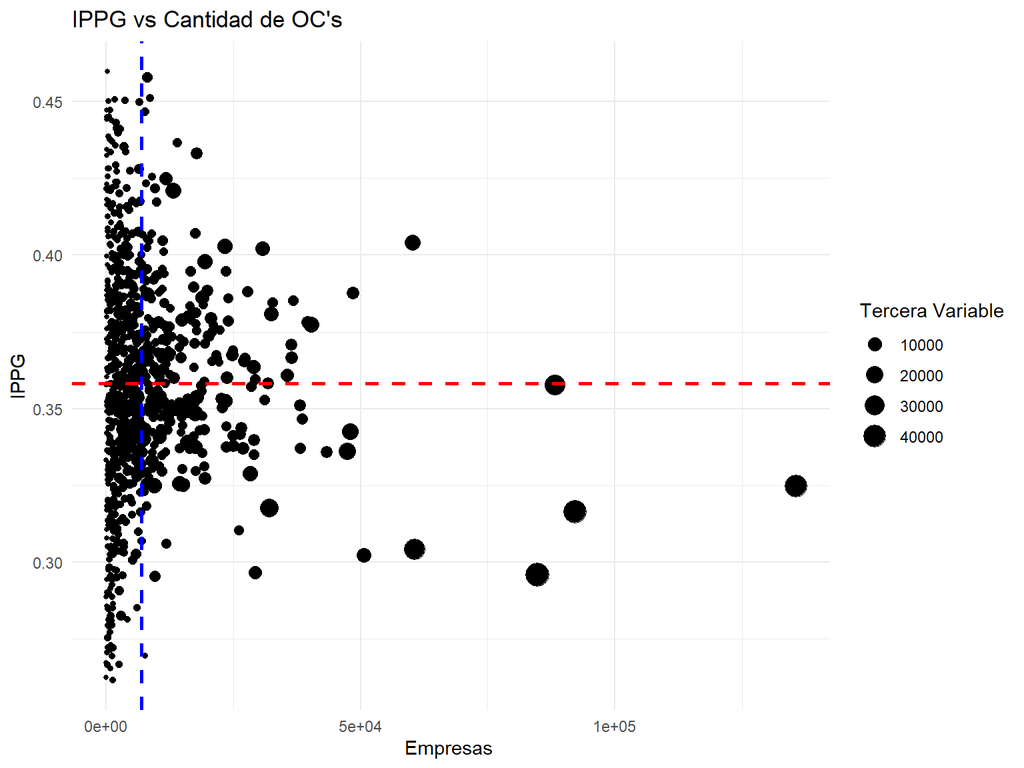

# Resultados preliminares: Ranking de instituciones

De un total de 961 entidades gubernamentales que operan a través del sistema, se procedió a rankear a cada una de acuerdo al resultado del índice.

# Resultados preliminares: Ranking de instituciones

| Institución | ratio adjudicación | ratio ofertas | indicador |
| --- | --- | --- | --- |
| CORPORACION MUNIC DE EDUC SALUD ATENCION | 0.06 | 0.10 | 0.08 |
| COMISION ADMINISTRADORA DEL SISTEMA DE CREDITOS P. ESTUDIOS SUPERIORES | 0.06 | 0.16 | 0.10 |
| FUNDACION PARA EL DESARROLLO DEL DEPORTE Y LA RECREACION DE LA COMUNA | 0.06 | 0.16 | 0.10 |
| I MUNICIPALIDAD DE ISLA DE PASCUA | 0.07 | 0.16 | 0.10 |
| DR. VICTOR HUGO MOLL DE CABILDO | 0.06 | 0.17 | 0.10 |
| DELEGACIÓN PRESIDENCIAL PROVINCIAL DEL TAMARUGAL | 0.08 | 0.14 | 0.10 |
| DELEGACIÓN PRESIDENCIAL PROVINCIAL DE CAPITÁN PRAT | 0.08 | 0.16 | 0.11 |
| Corporación Municipal de Deporte de Vitacura | 0.10 | 0.15 | 0.13 |
| DELEGACIÓN PRESIDENCIAL PROVINCIAL DE LINARES | 0.10 | 0.18 | 0.13 |
| SERVICIO DE VIVIENDA Y URBANIZACION III REGION | 0.15 | 0.12 | 0.14 |

Nota: Elaboración propia a partir de datos de ChileCompra

# Resultados preliminares: Ranking de instituciones

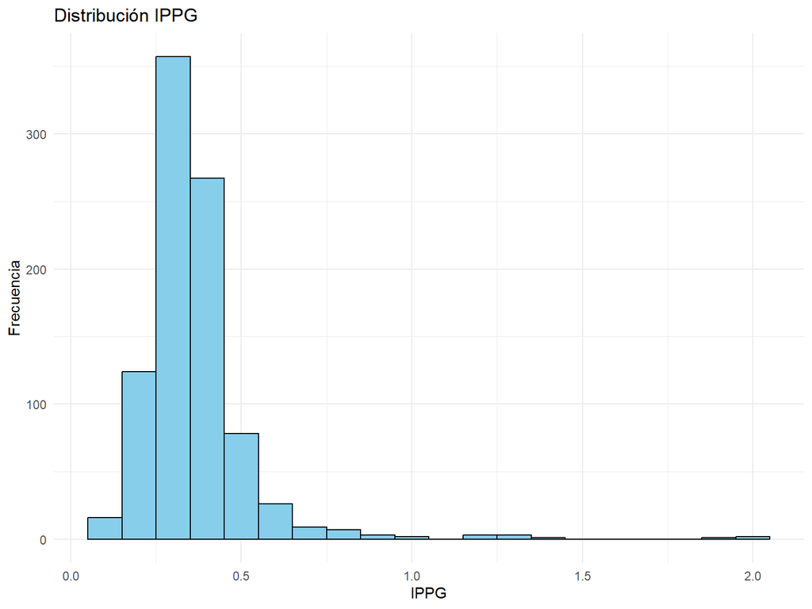

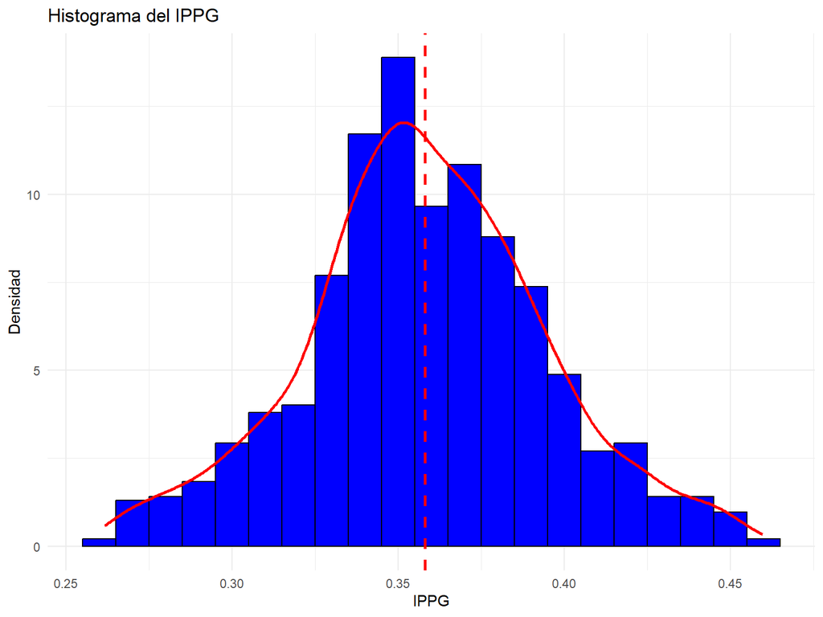

# Pasos a seguir

Más allá de los resultados preliminares aquí expuestos, quedan varios pasos a seguir, de enre los cuales se puede considerar:

- Considerar otros posibles universos en la construcción del índice: en esta propuesta se utilizaron las empresas participantes de la plataforma durante el año 2022, pero existen otros criterios que potencialmente pueden variar los resultados aquí presentados y que por tanto deben ser considerados para un ejercicio de análisis de sensibilidad.
- Es necesario definir si para el índice desagregado consideraremos sólo dos dimensiones o incluiremos la tercera a pesar de no variar.
- Queda pendiente analizar la evolución de otros indicadores propuestos en la minuta técnica de propuesta metodológica
- Calcular los índices complementarios propuestos por Permanyer (2010) con la finalidad de identificar con mayor precisión las manginitudes de las brechas y la severidad de las mismas.